# Filmy biograficzne na przestrzeni czasu i rozwoju kinematografii

Michał Wower

04.06.2023

# Wprowadzenie

Obranym za cel projektu jest analiza danych nt. filmów biograficznych wyprodukowanych na przestrzeni 100 lat. Zwrócono szczególną uwagę na cechy głównych postaci.

> [Film biograficzny – gatunek kina fabularnego, opowieść filmowa, której tematem jest życie i działalność sławnych ludzi](https://pl.wikipedia.org/wiki/Film_biograficzny)

Dane wykorzystane w owym projekcie zostały zgromadzone przez serwis [*IMDb*](https://www.imdb.com/) i podane obróbce przez strone [**fivethirtyeight**](https://fivethirtyeight.com/).

## Obróbka danych

Dane wczytano bezpośrednio z pakietu *fivethirtyeight*.

*Uwaga:Zmieniono kolejność kolumn.*

```r
db <- biopics[,c(1,3,4,5,6,7,8,9,13,14,11,12,10,2)]
```

Składają się z 761 rekordów i 14 zmiennych. Każdy rekord zawiera dane na temat osobnego bohatera.

## Wykorzystane zmienne

Analizie poddano następujące zmienne:

| Zmienna | Opis |
| --- | --- |
| *title* | tytuł |
| *country* | kraj/e produckji |
| *year_release* | rok produkcji |
| *box_office* | przychód w Stanach Zjednoczonych |
| *director* | reżyser |
| *number_of_subjects* | liczba bohaterów w filmie |
| *subject* | osoba o której jest dany film |
| *type_of subject* | zawód/zajęcie |
| *subject_sex* | płeć |
| *type_of_subject* | zawód/zajęcie |
| *lead_actor_actress* | aktor/ka grający/a główną rolę |
| *subject_race* | rasa |
| *person_of_color* | wskazuję czy osoba jest rasy białej czy innej |
| *race_known* | wskazuję czy znana jest rasa |
| *site* | adres URL do strony IMtitles |

```r
#zamianna niektórych zmiennych na faktory
db$country <- factor(db$country)
db$subject_race <- factor(db$subject_race)
db$type_of_subject <- factor(db$type_of_subject)
db$race_known <- factor(db$race_known)
db$subject_sex <- factor(db$subject_sex)
```

**Dodatkowo utworzono ramkę danych `titles`, aby wszelkie obliczenia były poprawne**

**Dobór ramki danych do obliczeń i wykresów został zdeterminowany przez pożądne w danym miejscu informacje**

```r
#utworzenie nowej ramki w której tytuły się nie powtarzają
titles <- db[!duplicated(db$title),]
```

Podsumowanie wybranych statystyk:

```r
knitr::kable(titles %>% select(year_release, box_office, subject_race, type_of_subject) %>% summary)
```

|  | year_release | box_office | subject_race | type_of_subject |
| --- | --- | --- | --- | --- |
|  | Min. :1915 | Min. : 3150 | White :373 | Other :138 |
|  | 1st Qu.:1968 | 1st Qu.: 1107500 | African American : 34 | Athlete : 68 |
|  | Median :1995 | Median : 6000000 | Multi racial : 20 | Criminal : 68 |
|  | Mean :1987 | Mean : 23558983 | Hispanic (Latin American): 13 | Historical: 64 |
|  | 3rd Qu.:2007 | 3rd Qu.: 30500000 | Middle Eastern (White) : 12 | Musician : 64 |
|  | Max. :2014 | Max. :350000000 | (Other) : 47 | Military : 44 |
|  | NA | NA’s :288 | NA’s :169 | (Other) :222 |

# Analiza

Zagadnienia poddane analizie:

- popularność filmów biograficznych
  - liczba produkcji
  - boxoffice’y
  - kraje przodujące w liczbie zrealizowanych filmów
- postać, na kanwie której stworzono film a jej cechy
  - profesja/powód stania się sławnym
  - zróżnicowanie rasowe
  - stosunek kobiet w stosunku do mężczyzn
- osoby zaangażowane w największą ilość filmów
- najbardziej kasowe filmy i osobe za nie odpowiedzialne

## Analiza trendu na przestrzeniu lat

Sprawdzono liczbę filmów biograficznych produkowanych w każdym roku oraz osiągniętym przychodzie z ich tytułu.

### Liczba filmów

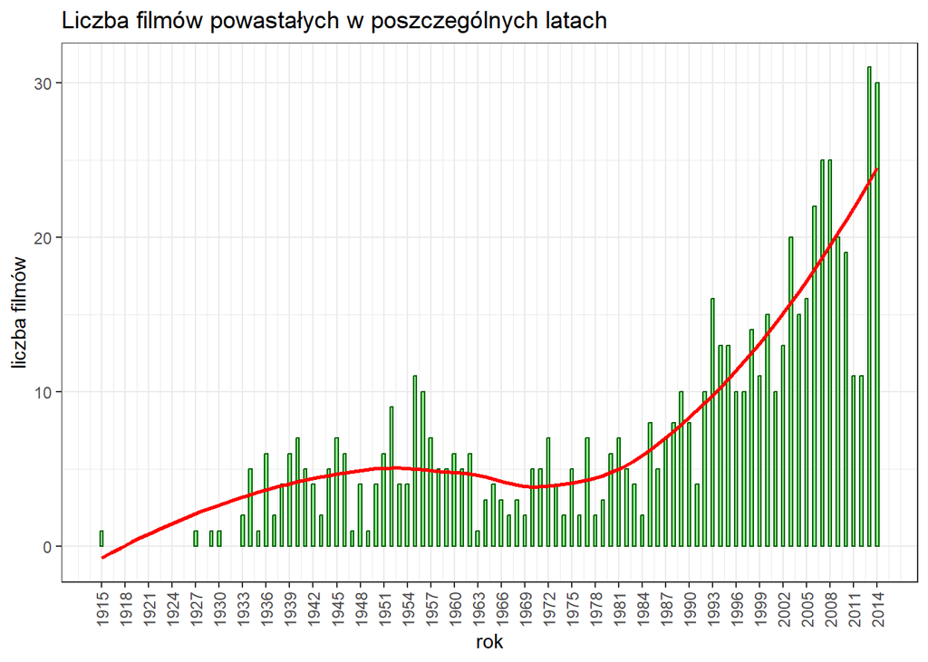

```r
titles %>%
  group_by(year_release) %>%
  summarise(n=n()) %>%
  ggplot(aes(x=year_release,y=n))+
  geom_col(fill="lightgreen",col="darkgreen",width = 0.4)+
  theme_bw()+
  ggtitle("Liczba filmów powastałych w poszczególnych latach")+
  xlab("rok")+
  ylab("liczba filmów")+
  scale_x_continuous(breaks = seq(1915,2014,3))+
  geom_smooth(col="red",se=F)+
  theme(axis.text.x = element_text(angle = 90, vjust = 0.5))
```

### Łączny przychód w całej branży z tytułu filmów biograficznych z podziałem na lata

*Uwaga: niestety aż* 288 *rekordów ma braki w columnie `box_office`, jednak mimo tego jesteśmy w stanie wyciągnąć merytoryczne wnioski*

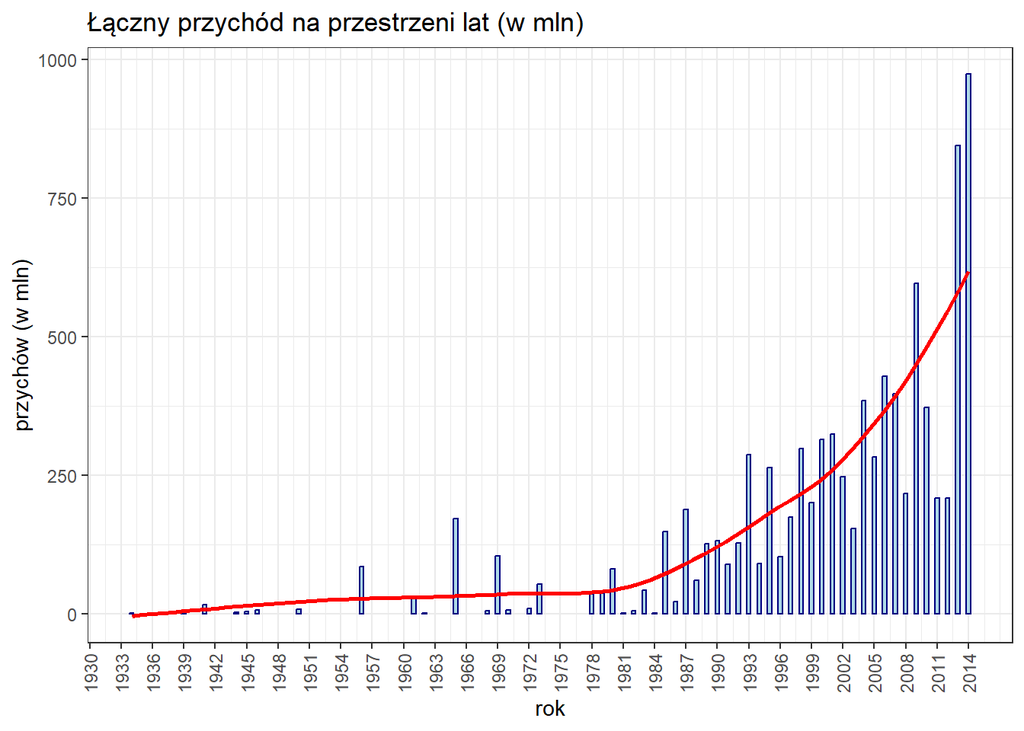

```r
### liczba zdarzen ####
titles %>%
  filter(box_office>0) %>%
  group_by(year_release) %>%
  summarise(sum_boxoffice=sum(box_office/1E6)) %>%
  ggplot(aes(x=year_release,y=sum_boxoffice))+
  geom_col(fill="lightblue",col="navy",width = 0.4)+
  theme_bw()+
  ggtitle("Łączny przychód na przestrzeni lat (w mln)")+
  xlab("rok")+
  ylab("przychów (w mln)")+
  scale_x_continuous(breaks = seq(1915,2014,3))+
  geom_smooth(col="red",se=F)+
  theme(axis.text.x = element_text(angle = 90, vjust = 0.5))
```

### Wiodące kraje pod względem liczby wypuszczonych filmów

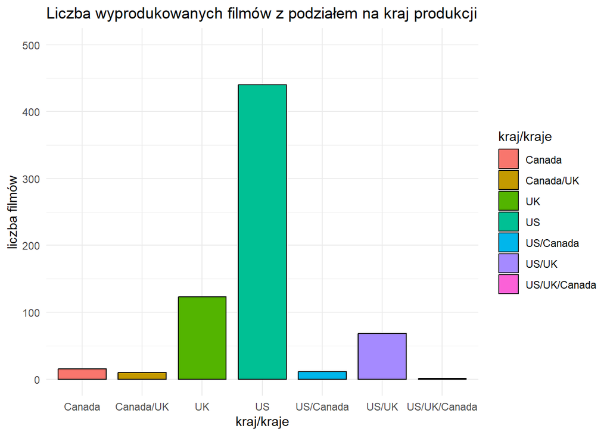

```r
titles %>%
  group_by(country) %>%
  summarise(n=n()) %>%
  ggplot(aes(x=country,y=n,fill=country))+
  geom_col(col="black",width=0.8,just = 0.5)+
  theme_minimal()+
  ylim(c(0,500))+
  ylab("liczba filmów")+
  xlab("kraj/kraje")+
  scale_fill_discrete(name = "kraj/kraje")+
  ggtitle("Liczba wyprodukowanych filmów z podziałem na kraj produkcji")
```

Niezaprzeczalnie głownym producentem takowych filmów są Stany Zjednoczone.

## Analiza cech bohatera

Przyjrzano się jakie cechy najczęściej chrakteryzuja postąć, o której nakręcono film. Mowa tu o płci, kolorze skóry, oraz powodzie, który sprawił, że dana osoba postrzegana jest jako sławna persona.

### Liczba głównych bohaterów

#### Częstość występowania w filmie więcej niż jednej głównej postaci

```r
knitr::kable(
  titles %>%
  group_by(number_of_subjects) %>%
  summarise(n=n()),
col.names=(c("główne postaci","liczba filmów"))
)
```

| główne postaci | liczba filmów |
| --- | --- |
| 1 | 590 |
| 2 | 69 |
| 3 | 7 |
| 4 | 2 |

Większość filmu opowiada o jednej osobie, zdarza się, że o dwóch, lecz o 3 albo 4 jedynie w pojedyńczych przypadkach

#### Filmy z większką liczbą głównych postaci niż 2

```r
knitr::kable(
  titles[,c(1,5,6)] %>%
    filter(number_of_subjects>2) %>%
    arrange(number_of_subjects)
)
```

| title | director | number_of_subjects |
| --- | --- | --- |
| A Dangerous Method | David Cronenberg | 3 |
| Cadillac Records | Darnell Martin | 3 |
| Devil’s Knot | Atom Egoyan | 3 |
| Devotion | Curtis Bernhardt | 3 |
| Escape from Alcatraz | Don Siegel | 3 |
| Henry & June | Philip Kaufman | 3 |
| Lords of Dogtown | Catherine Hardwicke | 3 |
| Jersey Boys | Clint Eastwood | 4 |
| The Bang Bang Club | Steven Silver | 4 |

Najwięcej (`4`) głównych bohaterów było w filmie The Bang Bang Club oraz Jersey Boys

### Profesja/zajęcie bohatera

*Uwaga: Tabela pomija wartość `Other`, lecz rekordy ją zawierające są brane do obliczeń procentowych.*

```r
knitr::kable(
db %>%
  filter(type_of_subject!="Other") %>%
  group_by(type_of_subject) %>%
  summarise(n=n(),
            udział_procentowy=n/nrow(titles)*100) %>%
  arrange(desc(n)),
col.names=c("zawód/zajęcie","liczba","udział w %")
)
```

| zawód/zajęcie | liczba | udział w % |
| --- | --- | --- |
| Criminal | 81 | 12.1257485 |
| Historical | 76 | 11.3772455 |
| Musician | 76 | 11.3772455 |
| Athlete | 74 | 11.0778443 |
| Author | 45 | 6.7365269 |
| Military | 45 | 6.7365269 |
| Activist | 31 | 4.6407186 |
| Artist | 29 | 4.3413174 |
| Academic | 21 | 3.1437126 |
| Singer | 20 | 2.9940120 |
| Actress | 17 | 2.5449102 |
| World leader | 17 | 2.5449102 |
| Media | 15 | 2.2455090 |
| Actor | 14 | 2.0958084 |
| Author (poet) | 13 | 1.9461078 |
| Medicine | 9 | 1.3473054 |
| Comedian | 7 | 1.0479042 |
| Government | 4 | 0.5988024 |
| Journalist | 2 | 0.2994012 |
| Academic (Philosopher) | 1 | 0.1497006 |
| Actress / activist | 1 | 0.1497006 |
| Athlete / military | 1 | 0.1497006 |
| Military / activist | 1 | 0.1497006 |
| Politician | 1 | 0.1497006 |
| Teacher | 1 | 0.1497006 |

Wyniki są zróżnicowane, jednak 4 wartości (“Criminal”,“Historical”,“Musician”,“Athlete”) zdają się delikatnie odstawać od reszty. Oznacza to, że główny bohater najczęściej był kryminalistą, postacią historyczną, muzykiem albo sportowcem.

#### Pod uwagę wzięto 4 najczęściej występujące wartości i porównano ich udział z biegem lat

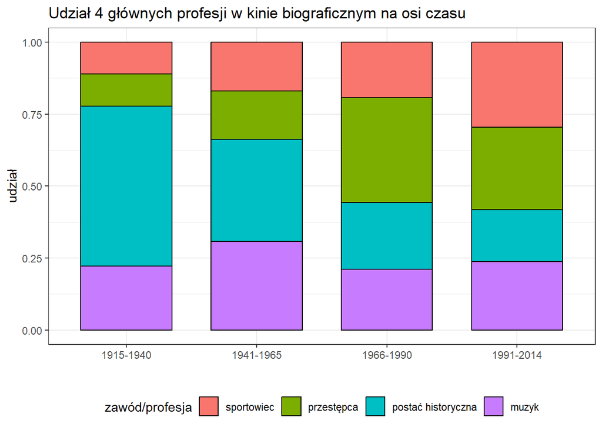

```r
db %>%
  filter(type_of_subject%in%c("Criminal","Historical","Musician","Athlete")) %>%
  mutate(breaks=cut(year_release,c(1915,1940,1965,1990,2015),labels = c("1915-1940","1941-1965","1966-1990","1991-2014"))) %>%
  group_by(breaks,type_of_subject) %>%
  summarise(n=n()) %>%
  ggplot(aes(x=breaks,y=n,fill=type_of_subject))+
  geom_col(position = "fill",col="black",width=0.7)+
  theme_bw()+
  theme(legend.position = "bottom")+
  ggtitle("Udział 4 głównych profesji w kinie biograficznym na osi czasu")+
  xlab("")+
  ylab("udział")+
  scale_fill_discrete(name = "zawód/profesja",labels=c("sportowiec","przestępca","postać historyczna","muzyk"))
```

Zauważono stały spadek udziału filmów o postaciach historycznych z biegiem czasu. W czasach powstawania kinematografii to one stanowiły trzon tematyczny filmów biograficznych. Ich miejsce zostało zastąpione przez produkcje o sportowcach oraz przestępcach. Warty odnotowania jest również fakt, że szczyt popularności filmów o kryminalistach miał miejsce w drugiej połowie XX w.

#### Przychody w owych 4 kategoriach

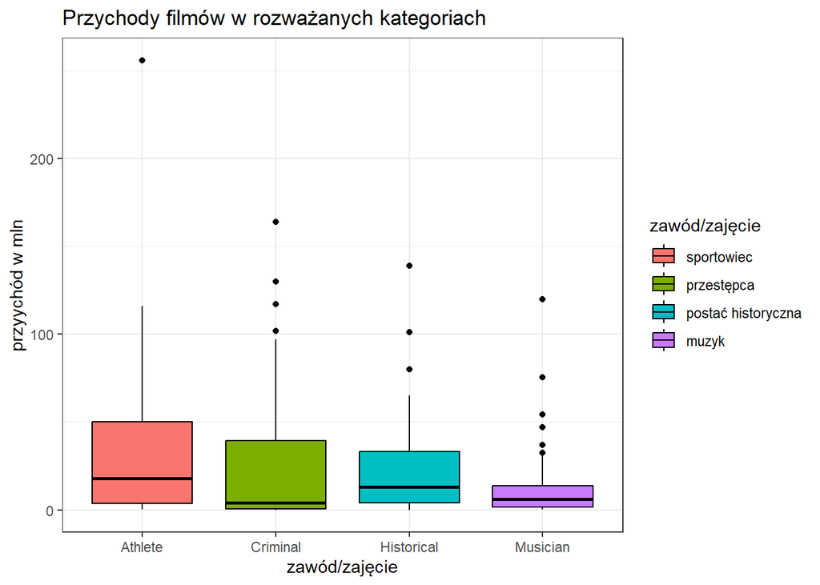

```r
titles %>%
  filter(!is.na(box_office)&type_of_subject%in%c("Criminal","Historical","Musician","Athlete")) %>%
  ggplot(aes(x=type_of_subject,y=box_office/1E6,fill=type_of_subject))+
  geom_boxplot(col="black")+
  xlab("zawód/zajęcie")+
  ylab("przyychód w mln")+
  ggtitle("Przychody filmów w rozważanych kategoriach")+
  theme_bw()+
  scale_fill_discrete(name = "zawód/zajęcie",labels=c("sportowiec","przestępca","postać historyczna","muzyk"))
```

Przychody z filmów biograficznych o muzykach zauważalnie są niższe niż pozostałych 3 kategorii. Natomiast średnio najbardziej opłacalne są filmy o sportowcach.

### Kolor skóry głównego bohatera

*Uwaga: We wszelakich obliczeniach pominięto* 169 *rekordów zawierających wartość `NA`. Oznacza to operowanie na* 74.7005988 *% rekordów*

#### Liczba zrezalizowanych produkcji z podziałem na rasę głównej postaci

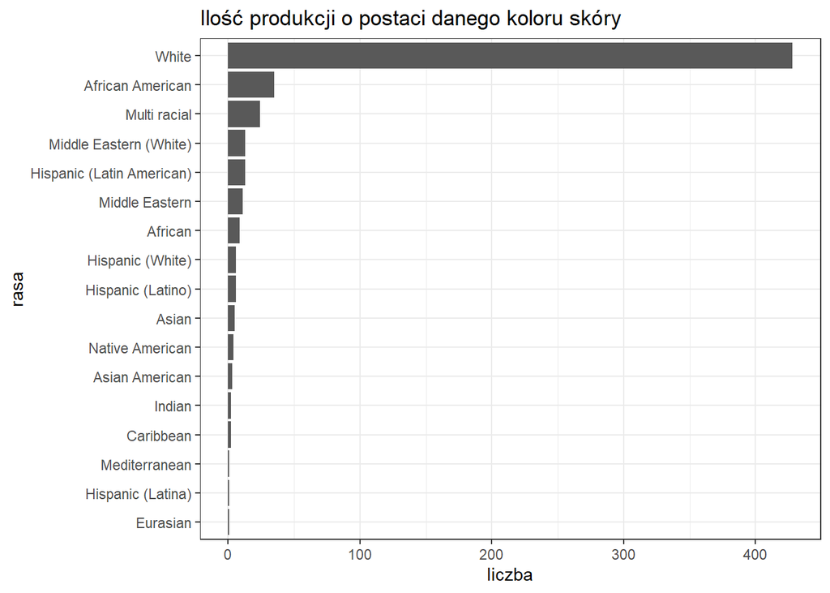

```r
db %>%
  filter(complete.cases(db$subject_race)) %>%
  group_by(subject_race) %>%
  summarise(n=n()) %>%
  arrange(desc(n)) %>%
  ggplot(aes(x=n,y=reorder(subject_race,n)))+
  geom_col()+
  xlab("liczba")+
  ylab("rasa")+
  ggtitle("Ilość produkcji o postaci danego koloru skóry")+
  theme_bw()
```

Zdecydowany prym wiodą osoby białoskóre. Dokładniej 75.8865248 % filmów jest o przedstawicielu tej rasy.

#### Udział rasowy w czterech wcześniej analizowanych profesjach, tj. Kryminalista, Postać Historyczna, Sportowiec, Muzyk

```r
knitr::kable(
db %>%
  filter(type_of_subject%in%c("Criminal","Historical","Musician","Athlete")&complete.cases(db$subject_race)) %>%
  group_by(type_of_subject,subject_race) %>%
  summarise(n=n()) %>%
  pivot_wider(names_from = type_of_subject,values_from = n,values_fill = F),
col.names = c("rasa bohatera","sportowiec","przestępca","postać historyczna","muzyk")
)
```

| rasa bohatera | sportowiec | przestępca | postać historyczna | muzyk |
| --- | --- | --- | --- | --- |
| African American | 13 | 2 | 0 | 5 |
| Asian American | 1 | 0 | 0 | 0 |
| Hispanic (Latino) | 2 | 1 | 0 | 1 |
| Hispanic (White) | 1 | 0 | 1 | 0 |
| Native American | 1 | 0 | 2 | 0 |
| White | 34 | 38 | 52 | 54 |
| Indian | 0 | 1 | 0 | 0 |
| Multi racial | 0 | 3 | 0 | 2 |
| Middle Eastern | 0 | 0 | 5 | 0 |
| Middle Eastern (White) | 0 | 0 | 13 | 0 |
| Caribbean | 0 | 0 | 0 | 1 |
| Hispanic (Latin American) | 0 | 0 | 0 | 1 |

Rasa biała ma niezaprzeczalną przegawę w każdej kategorii. Nie licząc pojedyńczych przypadków jedyne trendy tyczące się ras innych niż biała to afroamerykanie w filmach o sportowcach oraz przedstawiciele bliskiego wschodu w produkcjach o postaciach historycznych.

### Płeć postaci pierwszoplanowej

#### Udział procentowy kobiet i mężczyzn jako główny bohater/ka

```r
knitr::kable(
prop.table(table(db$subject_sex))*100,
col.names = c("płeć","udział w %")
)
```

| płeć | udział w % |
| --- | --- |
| Female | 23.25887 |
| Male | 76.74113 |

Mężczyzni stanowią ponad 3/4 głownych postaci.

#### Płeć na osi czasu

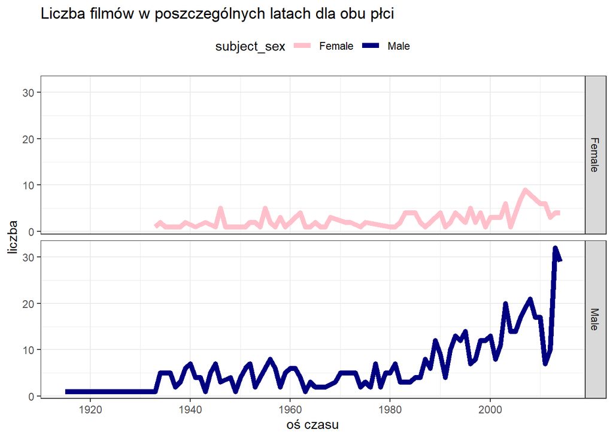

```r
db %>%
  group_by(subject_sex,year_release) %>%
  summarise(n=n()) %>%
  ggplot(aes(x=year_release,y=n,col=subject_sex))+
  geom_line(linewidth =2)+
  facet_grid(subject_sex~.)+
  theme_bw()+
  ggtitle("Liczba filmów w poszczególnych latach dla obu płci")+
  ylab("liczba")+
  xlab("oś czasu")+
  theme(legend.position = "top")+
  scale_color_manual(values=c("pink","navy"))
```

Chociaż od samemego początku kinematografii statystyka ta była na korzyść mężczyzn to z czasem przepaść się pogłębiała. Od około 2000 roku owa dysproporcja jedynie przybrała na szybkości powiększania się.

## Nazwiska związane z branżą

### Reżyserzy mający na swoim koncie najwięcej filmów biograficznych

```r
knitr::kable(
titles %>%
  group_by(director) %>%
  summarise(n=n()) %>%
  arrange(desc(n)) %>%
  head(10)
)
```

| director | n |
| --- | --- |
| Michael Curtiz | 8 |
| Richard Attenborough | 7 |
| Ken Russell | 6 |
| Martin Scorsese | 6 |
| Oliver Stone | 6 |
| Clint Eastwood | 5 |
| John Ford | 5 |
| Mervyn LeRoy | 5 |
| Richard Fleischer | 5 |
| Cecil B. DeMille | 4 |

Michael Curtiz ma najwięcej filmów biograficznych na swoim koncie.

#### Dwóch reżyserów z największą liczbą filmów biograficznych a charakterystyka owych filmów

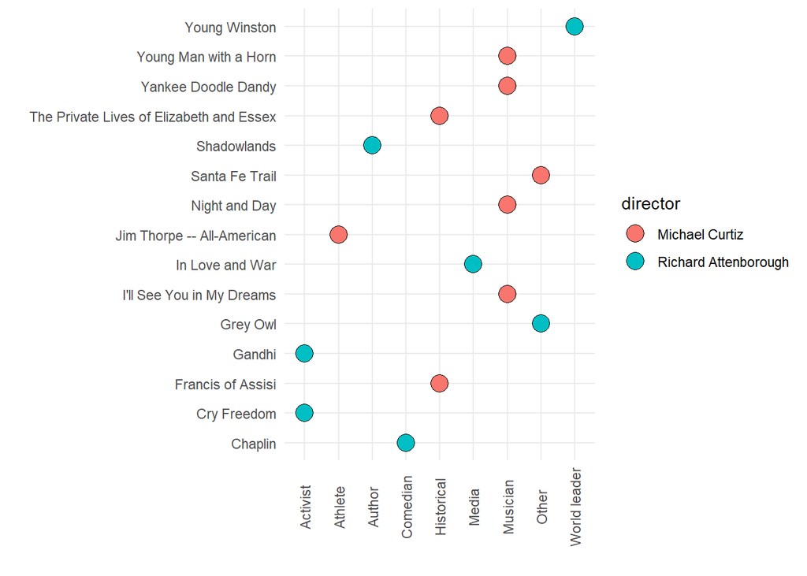

```r
titles %>%
  filter(director%in%c("Michael Curtiz","Richard Attenborough")) %>%
  ggplot(aes(x=type_of_subject,y=title,fill=director))+
  geom_point(pch=21,size=5,col="black")+
  theme_minimal()+
  theme(axis.text.x = element_text(angle = 90, vjust = 0.5))+
  xlab("")+
  ylab("")
```

Zauważono, że aż połowa filmów Michael’a Curtiz’a jest o muzykach. Natomiast dobór tematyki Richard’a Attenborought jest bardziej zróżnicowany.